# Análise de dados do TCC *Biogeografia do gênero Erythemis: um teste da regra de Baergmann*

Cibele Rosas Teixeira de Melo, Marcos Vinícius Carneiro Vital

22 de maio de 2017

## Apresentação

Este documento contem o script e resultados da análise de dados do TCC, e funciona como um registro reproduzível de todas as análises realizadas.

## Importação dos dados

Todos os dados utilizados foram condensados em uma única planilha:

```r
dados<-read.table("dados_cibele.txt", h=T, sep="\t")

summary(dados)
```

```
##              Espécie     Tamanho      Lat..Min.pontos  Lat..Max.pontos
##  E. carmelita    :1   Min.   :21.21   Min.   :-34.64   Min.   : 6.298
##  E. collocata    :1   1st Qu.:28.19   1st Qu.:-33.89   1st Qu.:22.017
##  E. credula      :1   Median :30.50   Median :-22.91   Median :35.457
##  E. haematogastra:1   Mean   :30.49   Mean   :-19.95   Mean   :31.873
##  E. mithroides   :1   3rd Qu.:33.11   3rd Qu.:-19.64   3rd Qu.:43.889
##  E. peruviana    :1   Max.   :39.46   Max.   : 18.02   Max.   :54.000
##  (Other)         :4
##    Diferença     Número.de.pontos
##  Min.   :25.94   Min.   :   3.0
##  1st Qu.:38.58   1st Qu.:  45.0
##  Median :50.80   Median : 117.5
##  Mean   :51.82   Mean   : 351.4
##  3rd Qu.:67.30   3rd Qu.: 272.5
##  Max.   :80.06   Max.   :2263.0
##
```

```r
attach(dados)
```

## Primeira análise, todas as espécies

Nesta primeira análise, vamos explorar os dados usando os dados de todas as espécies. É possível, porém, que as duas espécies que possuem distribuição mais restrita ao norte (simplicicolis e collocata) possam gerar ruído nas análises, uma vez que sua distribuição não ultrapassa a linha do equador, diferente de todas as demais.

**Latitude mínima**

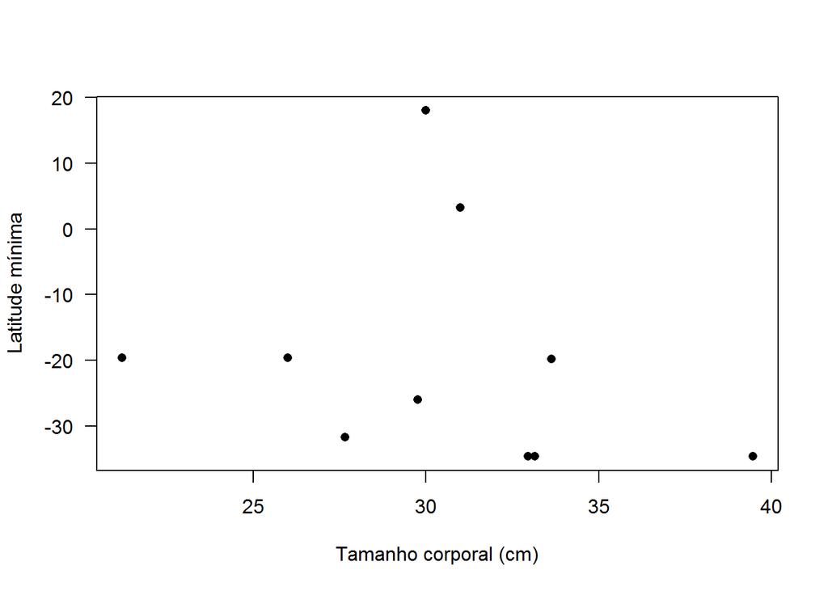

```r
plot(Lat..Min.pontos~Tamanho, pch=16, las=1, xlab="Tamanho corporal (cm)", ylab="Latitude mínima")
```

**Latitude máxima**

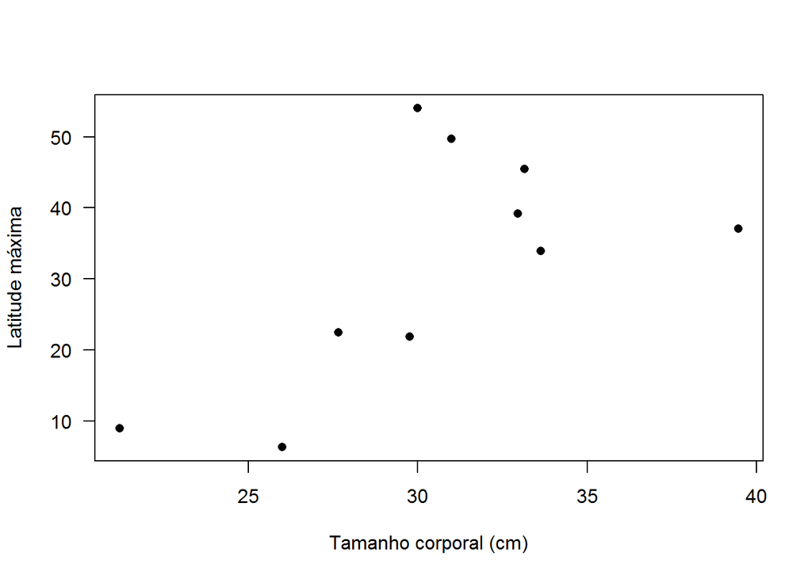

```r
plot(Lat..Max.pontos~Tamanho, pch=16, las=1, xlab="Tamanho corporal (cm)", ylab="Latitude máxima")
```

**Amplitude da latitude**

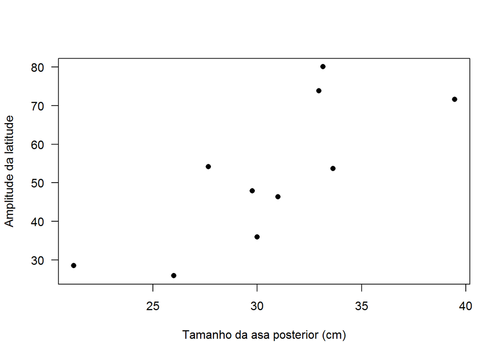

```r
plot(Diferença~Tamanho, pch=16, las=1, xlab="Tamanho da asa posterior (cm)", ylab="Amplitude da latitude")
```

Para a variação total da latitude, podemos manter todas as espécies e seguir com o teste de hipóteses nortmalmente! Não há por que retirar as duas espécies com distribuição diferente nesta análise.

```r
resultado.amplitude<-lm(Diferença~Tamanho)

summary(resultado.amplitude)
```

```
##
## Call:
## lm(formula = Diferença ~ Tamanho)
##
## Residuals:
##     Min      1Q  Median      3Q     Max
## -14.403  -7.327  -4.220   9.045  20.336
##
## Coefficients:
##             Estimate Std. Error t value Pr(>|t|)
## (Intercept) -38.2943    26.3602  -1.453  0.18437
## Tamanho       2.9559     0.8547   3.459  0.00859 **
## ---
## Signif. codes:  0 '***' 0.001 '**' 0.01 '*' 0.05 '.' 0.1 ' ' 1
##
## Residual standard error: 12.64 on 8 degrees of freedom
## Multiple R-squared:  0.5992, Adjusted R-squared:  0.5491
## F-statistic: 11.96 on 1 and 8 DF,  p-value: 0.008586
```

Existe uma relação clara, estatisticamente significativa, do tamanho corporal afetando a amplitude da latitude da distribuição. Cada cm a mais no tamanho da asa posterior da espécie gera um aumento médio de 2.9 graus decimais na amplitude da distribuição. O coeficiente de determinação foi de 0.55.

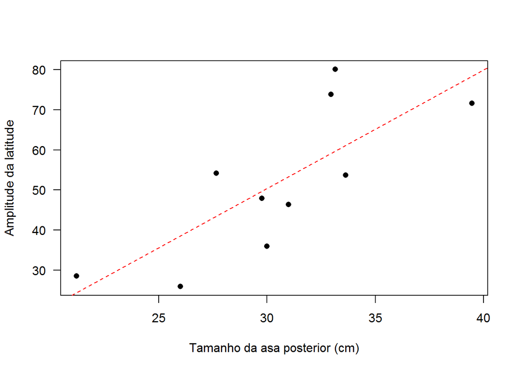

```r
plot(Diferença~Tamanho, pch=16, las=1, xlab="Tamanho da asa posterior (cm)", ylab="Amplitude da latitude")

abline(resultado.amplitude, col="red", lty=2)
```

## Segunda análise, apenas as “neotropicais”

Agora vamos seguir para avaliar de maneira direta a regra de Bergmann. Como explicado anteriormente, vamos remover duas espécies das análises.

**Re-ajustando os dados**

```r
detach(dados)

dados.novos<-dados[c(-3, -9),]

dados.novos
```

```
##             Espécie Tamanho Lat..Min.pontos Lat..Max.pontos Diferença
## 1          E.attala   32.96         -34.643          39.191     73.83
## 2      E. carmelita   21.21         -19.641           8.918     28.56
## 4        E. credula   26.00         -19.641           6.298     25.94
## 5  E. haematogastra   33.64         -19.805          33.889     53.69
## 6     E. mithroides   29.76         -26.019          21.887     47.91
## 7      E. peruviana   27.67         -31.765          22.407     54.17
## 8        E. plebeja   33.16         -34.603          45.455     80.06
## 10    E. vesiculosa   39.46         -34.643          37.025     71.67
##    Número.de.pontos
## 1               101
## 2                 3
## 4                 7
## 5                75
## 6                35
## 7               134
## 8               142
## 10              316
```

```r
attach(dados.novos)
```

**Latitude mínima**

A análise:

```r
resultado.latmin<-lm(Lat..Min.pontos~Tamanho)
summary(resultado.latmin)
```

```
##
## Call:
## lm(formula = Lat..Min.pontos ~ Tamanho)
##
## Residuals:
##     Min      1Q  Median      3Q     Max
## -6.4074 -4.9278  0.3357  1.8480 10.3018
##
## Coefficients:
##             Estimate Std. Error t value Pr(>|t|)
## (Intercept)  -3.3460    12.5963  -0.266   0.7994
## Tamanho      -0.7955     0.4073  -1.953   0.0986 .
## ---
## Signif. codes:  0 '***' 0.001 '**' 0.01 '*' 0.05 '.' 0.1 ' ' 1
##
## Residual standard error: 6.019 on 6 degrees of freedom
## Multiple R-squared:  0.3887, Adjusted R-squared:  0.2868
## F-statistic: 3.815 on 1 and 6 DF,  p-value: 0.09863
```

Aqui não temos uma relação estatisticamente significativa.

O gráfico:

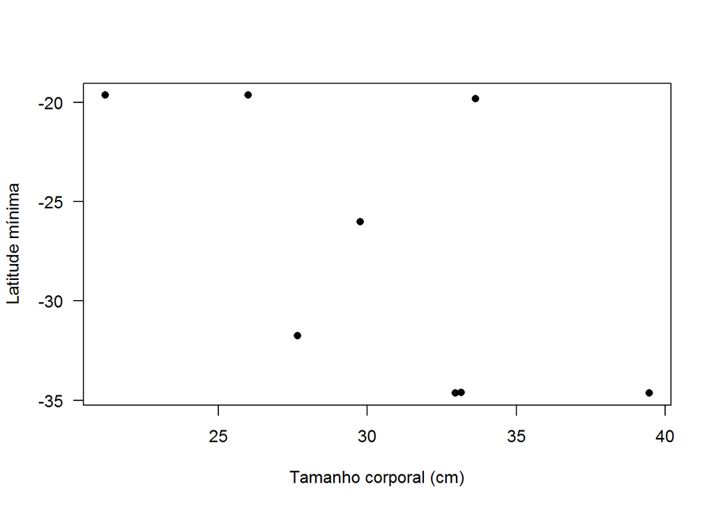

```r
plot(Lat..Min.pontos~Tamanho, pch=16, las=1, xlab="Tamanho corporal (cm)", ylab="Latitude mínima")
```

**Latitude máxima**

A análise:

```r
resultado.latmax<-lm(Lat..Max.pontos~Tamanho)
summary(resultado.latmax)
```

```
##
## Call:
## lm(formula = Lat..Max.pontos ~ Tamanho)
##
## Residuals:
##      Min       1Q   Median       3Q      Max
## -10.9703  -4.8643   0.8942   3.1918  12.8277
##
## Coefficients:
##             Estimate Std. Error t value Pr(>|t|)
## (Intercept) -38.5046    17.8192  -2.161  0.07399 .
## Tamanho       2.1451     0.5762   3.723  0.00982 **
## ---
## Signif. codes:  0 '***' 0.001 '**' 0.01 '*' 0.05 '.' 0.1 ' ' 1
##
## Residual standard error: 8.514 on 6 degrees of freedom
## Multiple R-squared:  0.6979, Adjusted R-squared:  0.6476
## F-statistic: 13.86 on 1 and 6 DF,  p-value: 0.009817
```

E aqui novamente temos um efeito significativo. Em média, cada cm de tamanho implica num aumento de 2.1 graus decimais na latitude máxima.

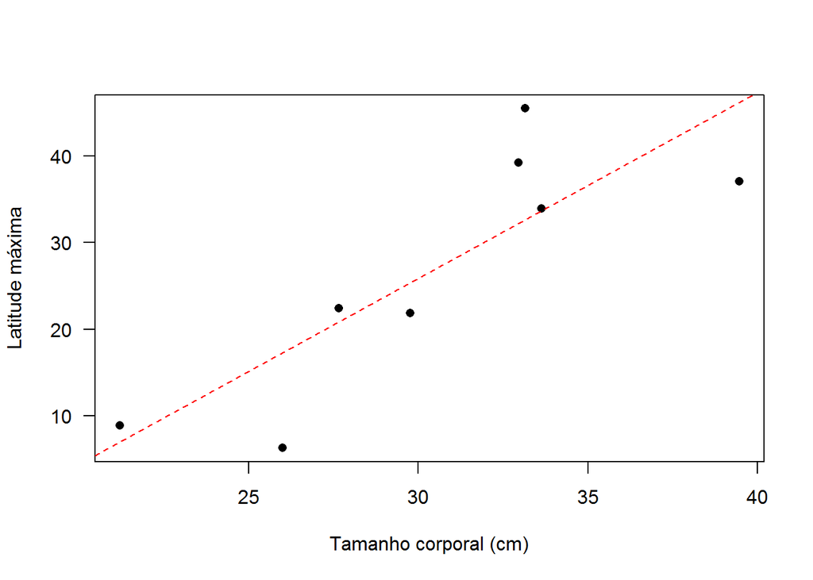

```r
plot(Lat..Max.pontos~Tamanho, pch=16, las=1, xlab="Tamanho corporal (cm)", ylab="Latitude máxima")

abline(resultado.latmax, col="red", lty=2)
```